# Непараметрический бутстрэп медианы массы пингвинов

Андреус Аглая Ашотовна, Б24-902

2026-11-01

## 1. Исходные данные и выборка

Изучается масса тела пингвинов трех видов из набора Palmer Penguins. Генеральная совокупность для практикума — **342 записи с известной массой**. Ее медиана нужна для проверки результата, но не участвует в построении бутстрэп-выборок или доверительного интервала. Стратификация не проводится.

```r
# Эти пакеты устанавливаются один раз перед первой сборкой:
# install.packages(c("palmerpenguins", "ggplot2", "knitr", "rmarkdown"))
library(palmerpenguins)
library(ggplot2)

population <- as.data.frame(
  penguins[!is.na(penguins$body_mass_g), c("species", "body_mass_g")]
)
rownames(population) <- NULL

# Указываем алгоритмы генератора, чтобы повторить заданную серию.
RNGkind(kind = "Mersenne-Twister", normal.kind = "Inversion",
        sample.kind = "Rejection")
set.seed(2026)
start_rows <- sample.int(342, size = 80, replace = TRUE)
initial_sample <- population[start_rows, , drop = FALSE]

all_masses <- population$body_mass_g
observed_masses <- initial_sample$body_mass_g
population_median <- median(all_masses)
sample_median <- median(observed_masses)

stopifnot(nrow(population) == 342L, nrow(initial_sample) == 80L,
          !anyNA(observed_masses))

show_number <- function(x) {
  format(x, digits = 10, trim = TRUE, scientific = FALSE)
}
knitr::kable(data.frame(
  Показатель = c("Объем совокупности", "Объем исходной выборки",
                "Медиана совокупности, г", "Медиана исходной выборки, г"),
  Значение = c(length(all_masses), length(observed_masses),
              population_median, sample_median)
), row.names = FALSE)
```

| Показатель | Значение |
| --- | --- |
| Объем совокупности | 342 |
| Объем исходной выборки | 80 |
| Медиана совокупности, г | 4050 |
| Медиана исходной выборки, г | 4300 |

Зерно исходного отбора — **2026**. Повторения записей допустимы: это 80 извлечений с возвращением. Порядок строк `population` не изменялся. Медиана совокупности — **4050 г**, медиана выборки — **4300 г**.

### Эмпирические функции распределения

Эмпирическая функция показывает долю наблюдений с массой не больше $x$: $F_n(x)=\#\{x_i\leq x\}/n$. Ступени выборочной функции крупнее, потому что в выборке всего 80 извлечений, а в совокупности 342 записи. Для сопоставления с образцом на рисунке соединены значения эмпирических функций в наблюдаемых точках; сами эмпирические функции ступенчатые.

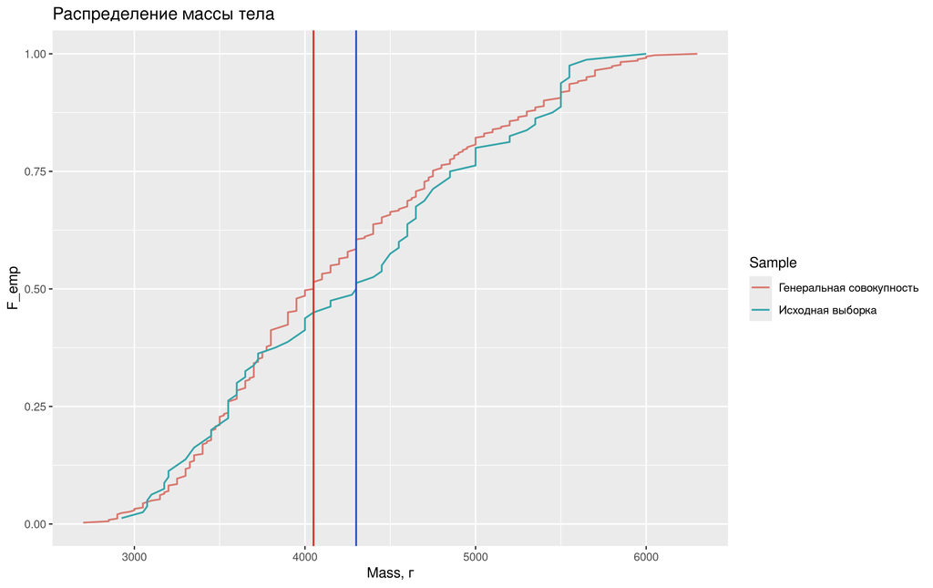

Рисунок 1. Эмпирические функции распределения. Вертикальные линии: красная — медиана совокупности, синяя — медиана исходной выборки.

```r
distribution_data <- rbind(
  data.frame(Mass = sort(all_masses),
             F_emp = seq_along(all_masses) / length(all_masses),
             Sample = "Генеральная совокупность"),
  data.frame(Mass = sort(observed_masses),
             F_emp = seq_along(observed_masses) / length(observed_masses),
             Sample = "Исходная выборка")
)

# Сортируются только копии масс для рисунка; исходные таблицы не меняются.
ggplot(distribution_data, aes(x = Mass, y = F_emp, color = Sample)) +
  geom_line(linewidth = 0.65) +
  geom_vline(xintercept = population_median, color = "#d73027", linewidth = 0.65) +
  geom_vline(xintercept = sample_median, color = "#2853b9", linewidth = 0.65) +
  scale_color_manual(values = c("Генеральная совокупность" = "#d87970",
                                "Исходная выборка" = "#36a5aa")) +
  labs(title = "Распределение массы тела", x = "Mass, г", y = "F_emp",
       color = "Sample")
```

Кривые близки, но не совпадают: случайный отбор меняет частоты масс, включает некоторые записи несколько раз и не включает другие. Выборочная медиана выше медианы совокупности на **250 г**.

### Гистограмма исходной выборки

Границы интервалов задаются явно. Это сохраняет положение и высоту столбцов при разных версиях `ggplot2`: 10 интервалов с центрами от минимальной до максимальной массы выборки.

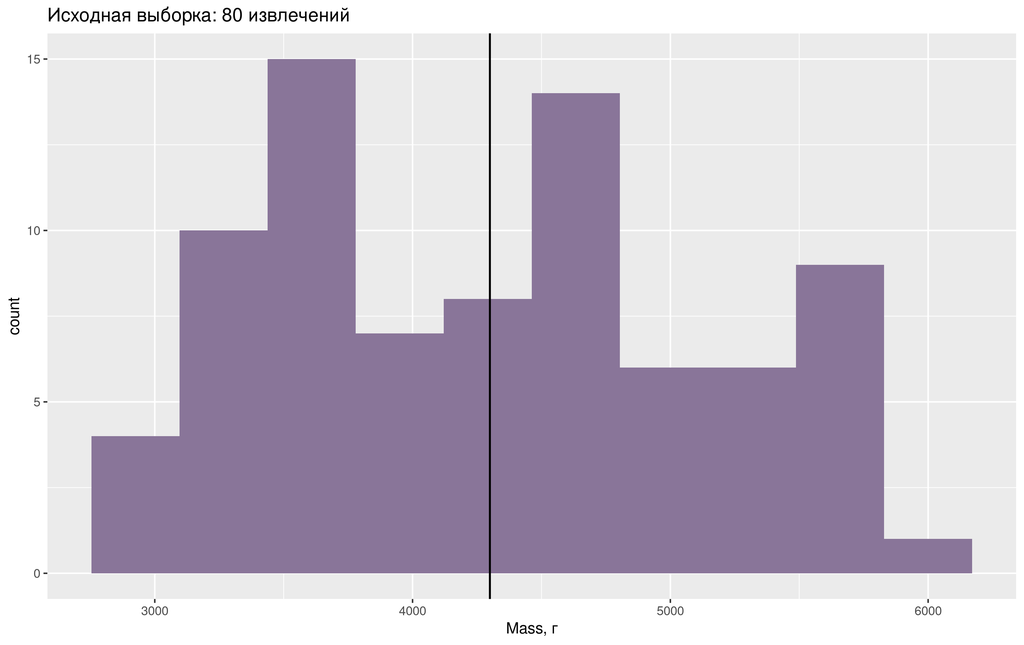

Рисунок 2. Масса тела в исходной выборке. Вертикальная линия — выборочная медиана.

```r
mass_bin_width <- diff(range(observed_masses)) / (10 - 1)
mass_limits <- seq(min(observed_masses) - mass_bin_width / 2,
                     max(observed_masses) + mass_bin_width / 2, length.out = 11)
hist_fill <- "#897599"

ggplot(data.frame(Mass = observed_masses), aes(x = Mass)) +
  geom_histogram(breaks = mass_limits, fill = hist_fill) +
  geom_vline(xintercept = sample_median, linewidth = 0.65) +
  labs(title = "Исходная выборка: 80 извлечений", x = "Mass, г", y = "count")
```

## 2. Одна последовательность бутстрэп-медиан

Зерно **2027** задается один раз перед циклом. Каждая новая выборка содержит 80 извлечений с возвращением **только из исходной выборки**.

```r
max_repeats <- 10000L
median_repeats <- numeric(max_repeats)

set.seed(2027)
for (iteration in seq_len(max_repeats)) {
  resample_rows <- sample.int(80, size = 80, replace = TRUE)
  bootstrap_sample <- initial_sample[resample_rows, , drop = FALSE]
  median_repeats[iteration] <- median(bootstrap_sample$body_mass_g)
}

stopifnot(length(median_repeats) == 10000L, all(is.finite(median_repeats)))
```

Вектор `median_repeats` сохраняет все 10 000 медиан **в порядке получения**. В следующих разделах он используется без нового моделирования.

## 3. Оценки и 95%-й процентильный интервал

Среднее бутстрэп-медиан оценивает центр бутстрэп-распределения. Стандартная ошибка — стандартное отклонение этих медиан. Бутстрэп-смещение считается относительно медианы исходной выборки:

$$\widehat{\mathrm{Bias}}=\overline{\theta^*}-\widehat\theta,
\qquad CI_{0.95}=[q_{0.025}(\theta^*);q_{0.975}(\theta^*)].$$

```r
average_median <- mean(median_repeats)
median_se <- sd(median_repeats)
median_bias <- average_median - sample_median
percentile_interval <- quantile(median_repeats, probs = c(0.025, 0.975),
                     type = 7, names = FALSE)
interval_width <- percentile_interval[2] - percentile_interval[1]
contains_population <- population_median >= percentile_interval[1] && population_median <= percentile_interval[2]

main_results <- data.frame(
  Показатель = c("Среднее бутстрэп-медиан, г", "Стандартная ошибка, г",
                "Бутстрэп-смещение, г", "Нижняя граница интервала, г",
                "Верхняя граница интервала, г", "Ширина интервала, г"),
  Значение = sapply(c(average_median, median_se, median_bias, percentile_interval, interval_width),
                   show_number),
  check.names = FALSE
)
knitr::kable(main_results, row.names = FALSE)
```

| Показатель | Значение |
| --- | --- |
| Среднее бутстрэп-медиан, г | 4287.33875 |
| Стандартная ошибка, г | 187.8657772 |
| Бутстрэп-смещение, г | -12.66125 |
| Нижняя граница интервала, г | 3950 |
| Верхняя граница интервала, г | 4600 |
| Ширина интервала, г | 650 |

Среднее бутстрэп-медиан — **4287.33875 г**. Оно отличается от выборочной медианы **4300 г** и медианы совокупности **4050 г**. Процентильный интервал — **[3950; 4600] г**, его ширина — **650 г**. Медиана полной совокупности **попадает** в этот интервал. Она не использовалась для его расчета.

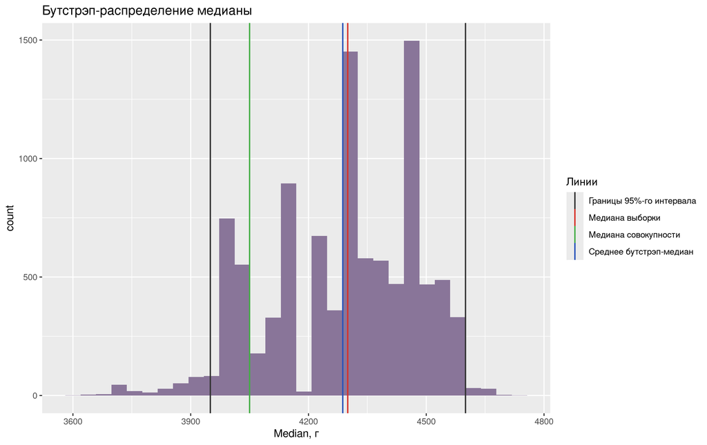

Рисунок 3. Распределение 10 000 бутстрэп-медиан. Отмечены медиана выборки, среднее бутстрэп-медиан, границы интервала и эталонная медиана.

```r
median_bin_width <- diff(range(median_repeats)) / (30 - 1)
median_limits <- seq(min(median_repeats) - median_bin_width / 2,
                   max(median_repeats) + median_bin_width / 2, length.out = 31)
reference_lines <- data.frame(
  Value = c(percentile_interval, sample_median, average_median, population_median),
  Role = c("Границы 95%-го интервала", "Границы 95%-го интервала",
           "Медиана выборки", "Среднее бутстрэп-медиан", "Медиана совокупности")
)

ggplot(data.frame(Median = median_repeats), aes(x = Median)) +
  geom_histogram(breaks = median_limits, fill = hist_fill) +
  geom_vline(data = reference_lines, aes(xintercept = Value, color = Role),
             linewidth = 0.65) +
  scale_color_manual(values = c("Границы 95%-го интервала" = "#333333",
                                "Медиана выборки" = "#d73027",
                                "Среднее бутстрэп-медиан" = "#2853b9",
                                "Медиана совокупности" = "#44ad45")) +
  labs(title = "Бутстрэп-распределение медианы", x = "Median, г", y = "count",
       color = "Линии")
```

## 4. Влияние числа повторений

Выполняется повышенный вариант: **100 значений $B$ от 100 до 10 000 с шагом 100**. Берутся вложенные начала одного сохраненного вектора. Объем каждой бутстрэп-выборки остается равным 80.

```r
repeat_grid <- seq(100L, max_repeats, by = 100L)
stability_results <- data.frame(
  B = repeat_grid, Mean = NA_real_, Deviation = NA_real_, SE = NA_real_,
  Lower = NA_real_, Upper = NA_real_, Width = NA_real_, Signed = NA_real_
)

for (position in seq_along(repeat_grid)) {
  b <- repeat_grid[position]
  first_medians <- median_repeats[seq_len(b)]
  average <- mean(first_medians)
  bounds <- quantile(first_medians, c(0.025, 0.975), type = 7, names = FALSE)
  stability_results$Mean[position] <- average
  stability_results$Deviation[position] <- abs(average - average_median)
  stability_results$SE[position] <- sd(first_medians)
  stability_results$Lower[position] <- bounds[1]
  stability_results$Upper[position] <- bounds[2]
  stability_results$Width[position] <- bounds[2] - bounds[1]
  stability_results$Signed[position] <- average - average_median
}
```

Ориентир — среднее при $B=10\,000$. Отклонение $D_B$ характеризует устойчивость вычисления, а не ошибку относительно медианы совокупности:

$$D_B=\left|\overline{\theta^*}_{1:B}
-\overline{\theta^*}_{1:10000}\right|.$$

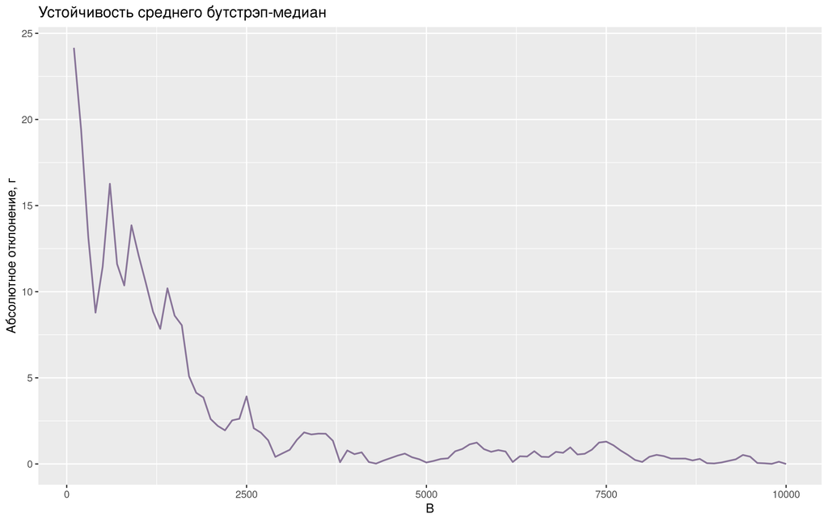

Рисунок 4. Абсолютное отклонение среднего бутстрэп-медиан от результата при B = 10 000 — график по условию.

```r
ggplot(stability_results, aes(x = B, y = Deviation)) +
  geom_line(color = hist_fill, linewidth = 0.7) +
  labs(title = "Устойчивость среднего бутстрэп-медиан", x = "B",
       y = "Абсолютное отклонение, г")
```

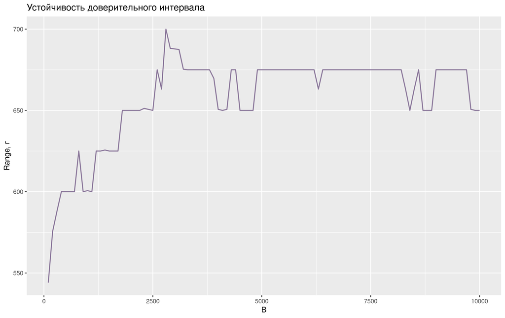

Рисунок 5. Ширина 95%-го процентильного интервала при добавлении новых бутстрэп-повторений.

```r
ggplot(stability_results, aes(x = B, y = Width)) +
  geom_line(color = hist_fill, linewidth = 0.7) +
  labs(title = "Устойчивость доверительного интервала", x = "B", y = "Range, г")
```

При $B=10\,000$ отклонение равно нулю **по определению ориентира**. Это не означает, что истинная медиана оценена без ошибки. Ширина интервала и отклонение меняются немонотонно, так как при добавлении медиан меняются эмпирические квантили и среднее.

## 5. Итоговая таблица

```r
report_sizes <- c(100, 1000, 2000, 5000, 10000)
report_rows <- stability_results[stability_results$B %in% report_sizes, ]
comparison_table <- data.frame(
  Показатель = c("Средняя бутстрэп-медиан, г", "Отклонение от B = 10 000, г",
                "Стандартная ошибка, г", "Нижняя граница интервала, г",
                "Верхняя граница интервала, г", "Ширина интервала, г"),
  check.names = FALSE
)
for (position in seq_len(nrow(report_rows))) {
  values <- c(report_rows$Mean[position], report_rows$Deviation[position], report_rows$SE[position],
              report_rows$Lower[position], report_rows$Upper[position], report_rows$Width[position])
  comparison_table[[as.character(report_rows$B[position])]] <-
    sapply(values, show_number)
}
knitr::kable(comparison_table, row.names = FALSE)
```

| Показатель | 100 | 1000 | 2000 | 5000 | 10000 |
| --- | --- | --- | --- | --- | --- |
| Средняя бутстрэп-медиан, г | 4311.5 | 4299.4375 | 4289.95 | 4287.425 | 4287.33875 |
| Отклонение от B = 10 000, г | 24.16125 | 12.09875 | 2.61125 | 0.08625 | 0 |
| Стандартная ошибка, г | 164.5862581 | 181.2755518 | 188.3522751 | 188.94016 | 187.8657772 |
| Нижняя граница интервала, г | 4000 | 3975 | 3925 | 3925 | 3950 |
| Верхняя граница интервала, г | 4544.0625 | 4575.625 | 4575 | 4600 | 4600 |
| Ширина интервала, г | 544.0625 | 600.625 | 650 | 675 | 650 |

Округление применяется только при выводе чисел. Все последующие расчеты выполняются по неокругленным значениям. Ширина при $B=100$ равна **544.0625 г**.

### Сохранение результатов

```r
save_folder <- "results_Andreus"
dir.create(save_folder, showWarnings = FALSE, recursive = TRUE)
write.csv(data.frame(Repeat = seq_len(max_repeats), Median = median_repeats),
          file.path(save_folder, "bootstrap_medians.csv"), row.names = FALSE)
write.csv(stability_results, file.path(save_folder, "stability_all_B.csv"),
          row.names = FALSE)
write.csv(report_rows, file.path(save_folder, "control_values.csv"), row.names = FALSE)
write.csv(data.frame(Draw = seq_len(80), Population_row = start_rows,
                     initial_sample),
          file.path(save_folder, "initial_sample.csv"), row.names = FALSE)
```

## 6. Выводы и ответы на вопросы

1. **Различия распределений и медиан.** Выборка случайна и содержит повторения. Частоты масс в ней отличаются от частот всей совокупности, поэтому функции распределения и медианы не обязаны совпадать. Здесь получены 4300 г по выборке и 4050 г по совокупности.
2. **Почему бутстрэп строится из исходной выборки?** Именно ее эмпирическое распределение заменяет неизвестное распределение в задаче оценивания. Отбор из 342 записей стал бы новым моделированием из известной совокупности и не оценивал бы неопределенность этой исходной выборки.
3. **Что показывает стандартная ошибка?** Разброс бутстрэп-медиан, то есть неопределенность оценки медианы. Получено **187.8657772 г**. Это отличается от стандартного отклонения масс отдельных птиц: оно описывает изменчивость признака, а не изменчивость оценки.
4. **Как влияет увеличение $B$?** Уменьшает вычислительные колебания среднего и квантилей бутстрэп-распределения. Однако на каждом отдельном шаге показатели могут колебаться в обе стороны.
5. **Почему интервал не обязан сужаться, а оценка — приближаться к истинной медиане?** Увеличивается число повторений, а не объем исходной выборки: он остается 80. Новая информация о совокупности не добавляется. Большое $B$ точнее описывает бутстрэп-распределение данной выборки, но не устраняет ее отличие от совокупности.
6. **Можно ли оценить покрытие по одному интервалу?** Нет. Здесь медиана совокупности 4050 г находится внутри [3950; 4600] г, но один такой исход не устанавливает фактическую вероятность покрытия. Для ее оценки нужны многие независимые исходные выборки и интервалы по каждой из них; в этом практикуме такое исследование не требуется.

Выводы относятся к заданной конечной совокупности из 342 записей. Среднее бутстрэп-медиан 4287.33875 г, выборочная медиана 4300 г и медиана совокупности 4050 г имеют разные назначения. Бутстрэп-смещение относительно выборочной медианы равно **-12.66125 г**.

## Дополнение: сопоставление с графиком образца

В графике образца, подписанном `Bias`, есть отрицательные значения. Поэтому для сопоставления ниже показана **знаковая вычислительная разность** $\overline{\theta^*}_{1:B}-\overline{\theta^*}_{1:10000}$. Это отдельный показатель: он не равен абсолютному отклонению из условия и не равен бутстрэп-смещению относительно выборочной медианы. Обязательный график абсолютного отклонения приведен на рисунке 4.

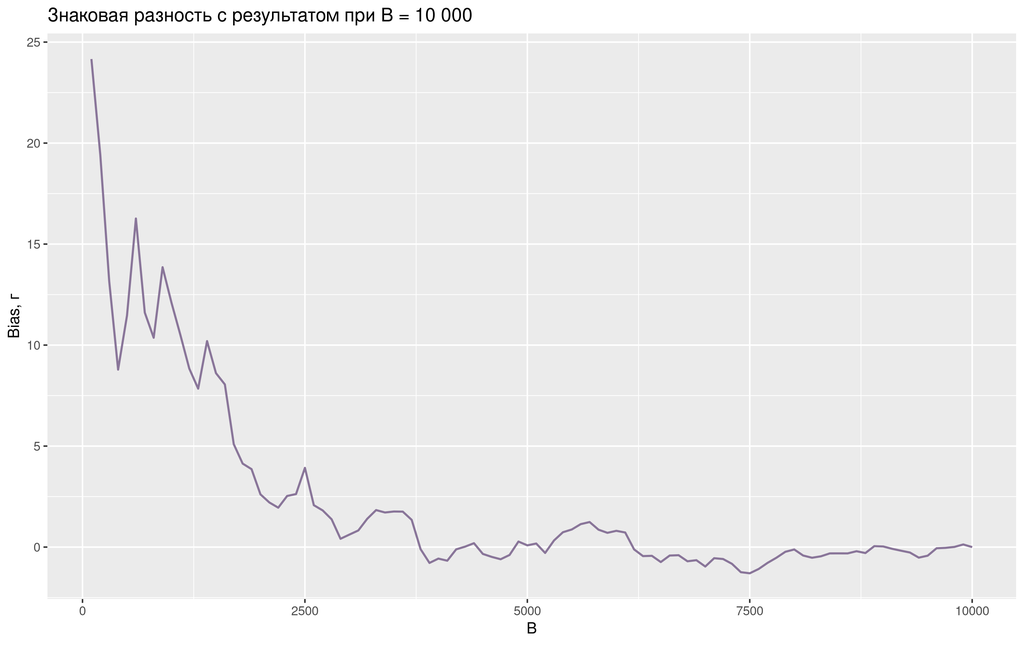

Дополнительный рисунок. Знаковая разность с вычислительным ориентиром — для сопоставления с графиком Bias из образца.

```r
ggplot(stability_results, aes(x = B, y = Signed)) +
  geom_line(color = hist_fill, linewidth = 0.7) +
  labs(title = "Знаковая разность с результатом при B = 10 000",
       x = "B", y = "Bias, г")
```

Источники: условие `practicum_penguins_bootstrap.pdf`; пакет `palmerpenguins` версии 0.1.1; Gorman, Williams, Fraser (2014), DOI: 10.1371/journal.pone.0090081.

Для сборки открыть `.Rmd` в RStudio и нажать **Knit**. Дополнительные исходные CSV или XLSX не нужны: данные поступают из пакета. В отчете видны R-код, результаты, таблицы и все графики.